# Practical Machine Learning - Assignment

Sébastien Lievain

03/01/2017

## Executive Summary

In this project, we will use data from accelerometers on the belt, forearm, arm, and dumbell of 6 participants. They were asked to perform barbell lifts correctly and incorrectly in 5 different ways.  
The goal is to predict the manner in which they did the exercise.

## Data Loading and Cleaning

The data for this project comes from this source: http://groupware.les.inf.puc-rio.br/har.

```r
library(parallel)
library(doParallel)
library(caret)
library(randomForest)

dir.create("data", showWarnings = FALSE)

if(!file.exists("data/pml-training.csv") | !file.exists("data/pml-training.csv")) {
    download.file("https://d396qusza40orc.cloudfront.net/predmachlearn/pml-training.csv",
                  "data/pml-training.csv", method = "curl")
    download.file("https://d396qusza40orc.cloudfront.net/predmachlearn/pml-testing.csv",
                  "data/pml-testing.csv", method = "curl")
}

pmlTraining <- read.csv("data/pml-training.csv", na.strings = c("#DIV/0!", "NA"))
testing <- read.csv("data/pml-testing.csv", na.strings = c("#DIV/0!", "NA"))
```

The `cvtd_timestamp` variable was loaded as a `factor` instead of a `Date`.  
The `X` variable won’t be of any interest in our study:

```r
library(lubridate)

# transforming cvtd_timestamp variable into a Date
pmlTraining$cvtd_timestamp <- dmy_hm(pmlTraining$cvtd_timestamp)
testing$cvtd_timestamp <- dmy_hm(testing$cvtd_timestamp)

# Removing first column
pmlTraining <- pmlTraining[, !(names(pmlTraining) %in% c("X"))]
testing <- testing[, !(names(testing) %in% c("X"))]
```

Data has been captured by sensors during the practice of barbell lifts. Data is therfore temporal!  
Two approaches are possible to analyse such data:

- Analysing all data points during the practice
- Aggregating data on small windows of time (2.5 sec here) and only analyse these aggregated data points.

The second approach can be challenging:

- How long should windows be?
- Should they all be of the same length?
- When to start and stop a window?
- Should windows overlap?

but also rewarding:

- Timely patterns can better be captured: e.g. the amplitude of the movement of the dumbbell can detect two wrong habits:
  - lifting the dumbbell only halfway (Class C),
  - lowering the dumbbell only halfway (Class D).
- Once data points have been aggregated (initial cost), computation cost is much cheaper for future analyses.

In the training dataset, these aggregated data points are indicated by the `new_window` variable.  
Unfortunatelly, no aggregated data point is present in the testing dataset!! Making impossible this second approach.

Therefore, all 100 aggregated features can be removed as well as ones about windows:

```r
agg_features <- c(
    "min_roll_belt", "min_roll_dumbbell", "min_roll_arm", "min_roll_forearm",
    "min_pitch_belt", "min_pitch_dumbbell", "min_pitch_arm", "min_pitch_forearm",
    "min_yaw_belt", "min_yaw_dumbbell", "min_yaw_arm", "min_yaw_forearm",
    "max_roll_belt", "max_roll_dumbbell", "max_roll_arm", "max_roll_forearm",
    "max_picth_belt", "max_picth_dumbbell", "max_picth_arm", "max_picth_forearm",
    "max_yaw_belt", "max_yaw_dumbbell", "max_yaw_arm", "max_yaw_forearm",
    "amplitude_roll_belt", "amplitude_roll_dumbbell", "amplitude_roll_arm",
    "amplitude_roll_forearm", "amplitude_pitch_belt", "amplitude_pitch_dumbbell",
    "amplitude_pitch_arm", "amplitude_pitch_forearm", "amplitude_yaw_belt",
    "amplitude_yaw_dumbbell", "amplitude_yaw_arm", "amplitude_yaw_forearm",
    "kurtosis_roll_belt", "kurtosis_roll_dumbbell", "kurtosis_roll_arm",
    "kurtosis_roll_forearm", "kurtosis_picth_belt", "kurtosis_picth_dumbbell",
    "kurtosis_picth_arm", "kurtosis_picth_forearm", "kurtosis_yaw_belt",
    "kurtosis_yaw_dumbbell", "kurtosis_yaw_arm", "kurtosis_yaw_forearm",
    "skewness_roll_belt", "skewness_roll_dumbbell", "skewness_roll_arm",
    "skewness_roll_forearm", "skewness_roll_belt.1", "skewness_pitch_dumbbell",
    "skewness_pitch_arm", "skewness_pitch_forearm", "skewness_yaw_belt",
    "skewness_yaw_dumbbell", "skewness_yaw_arm", "skewness_yaw_forearm",
    "avg_roll_belt", "avg_roll_dumbbell", "avg_roll_arm", "avg_roll_forearm",
    "avg_pitch_belt", "avg_pitch_dumbbell", "avg_pitch_arm", "avg_pitch_forearm",
    "avg_yaw_belt", "avg_yaw_dumbbell", "avg_yaw_arm", "avg_yaw_forearm",
    "stddev_roll_belt", "stddev_roll_dumbbell", "stddev_roll_arm",
    "stddev_roll_forearm", "stddev_pitch_belt", "stddev_pitch_dumbbell",
    "stddev_pitch_arm", "stddev_pitch_forearm", "stddev_yaw_belt",
    "stddev_yaw_dumbbell", "stddev_yaw_arm", "stddev_yaw_forearm",
    "var_roll_belt", "var_roll_dumbbell", "var_roll_arm", "var_roll_forearm",
    "var_pitch_belt", "var_pitch_dumbbell", "var_pitch_arm", "var_pitch_forearm",
    "var_yaw_belt", "var_yaw_dumbbell", "var_yaw_arm", "var_yaw_forearm",
    "var_total_accel_belt", "var_accel_dumbbell", "var_accel_arm", "var_accel_forearm")

pmlTraining <- pmlTraining[, !(names(pmlTraining) %in% c(agg_features,
                                                         "new_window", "num_window"))]
```

Furthermore, Euler angles (roll, pitch and yaw) have been calculated from IMUs records (accelerometer, gyroscope and magnetometer). Therefore, only features from one out of the two systems should be used. I decided to use those from the Euler system:

```r
IMU_features <- c(
    "gyros_belt_x", "gyros_dumbbell_x", "gyros_arm_x", "gyros_forearm_x",
    "gyros_belt_y", "gyros_dumbbell_y", "gyros_arm_y", "gyros_forearm_y",
    "gyros_belt_z", "gyros_dumbbell_z", "gyros_arm_z", "gyros_forearm_z",
    "accel_belt_x", "accel_dumbbell_x", "accel_arm_x", "accel_forearm_x",
    "accel_belt_y", "accel_dumbbell_y", "accel_arm_y", "accel_forearm_y",
    "accel_belt_z", "accel_dumbbell_z", "accel_arm_z", "accel_forearm_z",
    "magnet_belt_x", "magnet_dumbbell_x", "magnet_arm_x", "magnet_forearm_x",
    "magnet_belt_y", "magnet_dumbbell_y", "magnet_arm_y", "magnet_forearm_y",
    "magnet_belt_z", "magnet_dumbbell_z", "magnet_arm_z", "magnet_forearm_z")

pmlTraining <- pmlTraining[, !(names(pmlTraining) %in% c(IMU_features))]
```

## Model creation

After several tests, random forest seems to be the best algorithm for the current application.

```r
cluster <- makeCluster(detectCores() - 1) # convention to leave 1 core for OS
registerDoParallel(cluster)

# First approach: all data points are taken into account
formula <- as.formula("classe ~ roll_belt + pitch_belt + yaw_belt + roll_dumbbell + roll_arm + roll_forearm + pitch_dumbbell + pitch_arm + pitch_forearm + yaw_dumbbell + yaw_arm + yaw_forearm")

modelFit <- train(formula, method = "rf", data = pmlTraining, importance = TRUE,
                  trControl = trainControl(method = "cv", number = 10, allowParallel = TRUE))

stopCluster(cluster)
registerDoSEQ()
```

## Cross Validation

```r
confusionMatrix.train(modelFit)
```

```
## Cross-Validated (10 fold) Confusion Matrix
##
## (entries are percentual average cell counts across resamples)
##
##           Reference
## Prediction    A    B    C    D    E
##          A 28.4  0.1  0.0  0.0  0.0
##          B  0.1 19.0  0.1  0.0  0.0
##          C  0.0  0.2 17.2  0.1  0.1
##          D  0.0  0.0  0.1 16.3  0.0
##          E  0.0  0.0  0.0  0.0 18.2
##
##  Accuracy (average) : 0.9907
```

The average accuracy is therefore 99.07%.

By applying cross validation, the best tuning parameters were looked at.  
For the random forest algorithm, only the `mtry` parameter (number of variables randomly sampled as candidates at each split) can be optimized.

```r
modelFit$results
```

```
##   mtry  Accuracy     Kappa  AccuracySD     KappaSD
## 1    2 0.9895013 0.9867197 0.003516756 0.004449189
## 2    7 0.9907248 0.9882681 0.003064712 0.003876687
## 3   12 0.9869026 0.9834346 0.004256671 0.005383633
```

We can see that the best accuracy (99.07%) is obtained with the `mtry` parameter set to 7.

## Expected Out of Sample Error

Our final Model has an out-of-bag error rate of 0.91%.

For informational purposes a plot of the error rate versus number of trees is also shown.

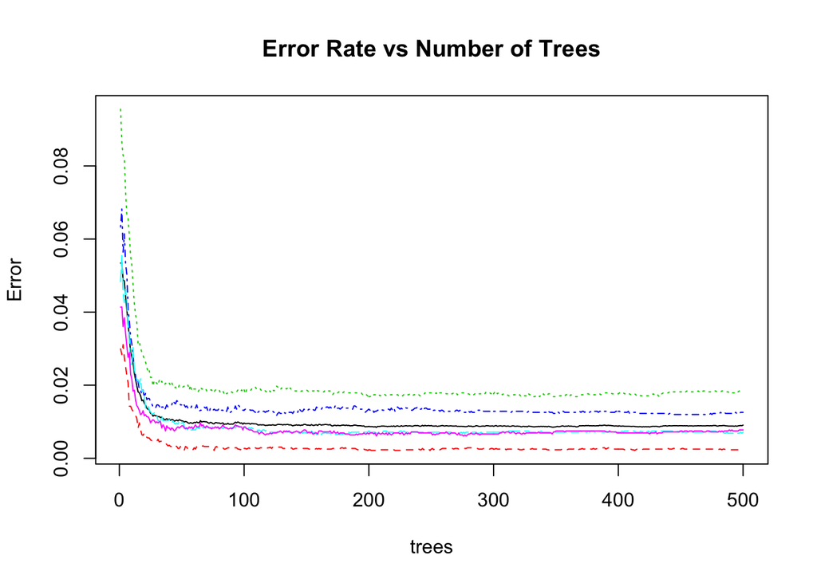

```r
plot(modelFit$finalModel, main = "Error Rate vs Number of Trees")
```

## Variables importance

The importance of each variable can be represented by the Mean Decrease in Accuracy or Gini index:

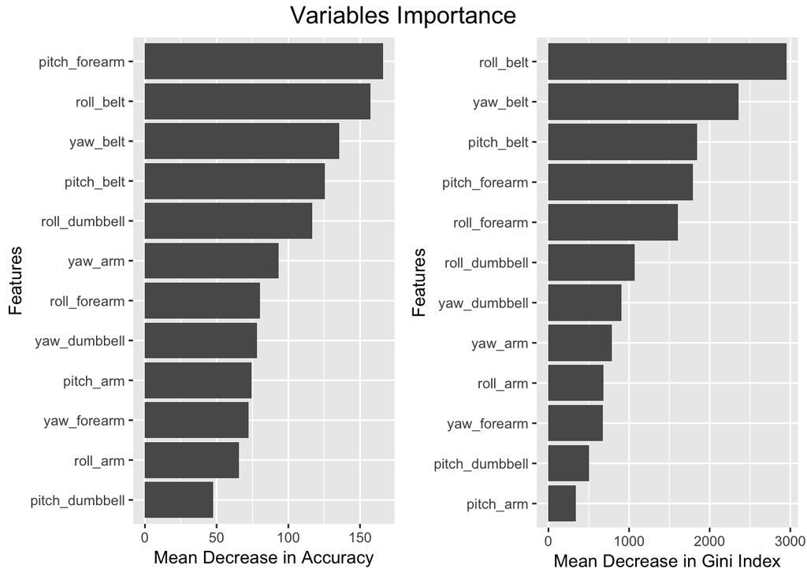

```r
library(grid)
library(gridExtra)
library(ggplot2)

importance <- as.data.frame(importance(modelFit$finalModel))
importance$features <- rownames(importance)

plot1 <- ggplot(importance, aes(
        x = reorder(features, MeanDecreaseAccuracy),
        y = MeanDecreaseAccuracy)
    ) +
    geom_bar(stat = "identity") +
    xlab("Features") +
    ylab("Mean Decrease in Accuracy") +
    coord_flip()

plot2 <- ggplot(importance, aes(
        x = reorder(features, MeanDecreaseGini),
        y = MeanDecreaseGini)
    ) +
    geom_bar(stat = "identity") +
    xlab("Features") +
    ylab("Mean Decrease in Gini Index") +
    coord_flip()

grid.arrange(plot1, plot2, ncol = 2,
             top = textGrob("Variables Importance", gp = gpar(fontsize = 15, font = 8)))
```

## Predicting classes from testing data

We can use the model we previously built to predict the class from testing data:

```r
predict(modelFit, newdata = testing)
```

```
##  [1] B A B A A E D B A A B C B A E E A B B B
## Levels: A B C D E
```

This ends up the assignment!

## Annexe: Second Approach

For those who are interested in the second approach. I will cover it as much as possible below.

First, let’s filter non-aggregated lines:

```r
# Second approach: only new window points are taken into account
# Reading file again
pmlTraining <- read.csv("data/pml-training.csv", na.strings = c("#DIV/0!", "NA"))
pmlTraining$cvtd_timestamp <- dmy_hm(pmlTraining$cvtd_timestamp)
pmlTraining <- pmlTraining[, !(names(pmlTraining) %in% c("X"))]

training_agg_lines <- pmlTraining[pmlTraining$new_window == "yes", ]
not_agg_features <- names(training_agg_lines)[!(names(training_agg_lines) %in% agg_features)]
```

During the aggregation process certain statistics have not been calculated resulting in NAs:

```r
library(mice)
library(VIM)
library(pander)

#exploring missing data
countNA <- t(t(sapply(agg_features, function(feature) {
    sum(is.na(training_agg_lines[, feature]))
})))
featuresToInvestigate <- agg_features[countNA != 0]

pander(t(md.pattern(training_agg_lines[, featuresToInvestigate])), split.table = 100)
```

|  | 217 | 16 | 5 | 69 | 1 | 3 | 6 | 1 | 2 | 1 | 71 | 4 | 1 | 6 | 1 | 1 | 1 |  |
| --- | --- | --- | --- | --- | --- | --- | --- | --- | --- | --- | --- | --- | --- | --- | --- | --- | --- | --- |
| **skewness_pitch_dumbbell** | 1 | 1 | 1 | 1 | 1 | 1 | 1 | 1 | 1 | 0 | 1 | 1 | 1 | 1 | 1 | 1 | 1 | 1 |
| **kurtosis_picth_dumbbell** | 1 | 1 | 1 | 1 | 1 | 1 | 1 | 1 | 1 | 0 | 1 | 1 | 1 | 1 | 1 | 1 | 0 | 2 |
| **skewness_roll_dumbbell** | 1 | 1 | 1 | 1 | 1 | 0 | 1 | 1 | 1 | 0 | 1 | 1 | 1 | 1 | 1 | 1 | 1 | 4 |
| **min_yaw_dumbbell** | 1 | 1 | 1 | 1 | 1 | 0 | 1 | 1 | 1 | 0 | 1 | 1 | 1 | 1 | 1 | 1 | 0 | 5 |
| **max_yaw_dumbbell** | 1 | 1 | 1 | 1 | 1 | 0 | 1 | 1 | 1 | 0 | 1 | 1 | 1 | 1 | 1 | 1 | 0 | 5 |
| **amplitude_yaw_dumbbell** | 1 | 1 | 1 | 1 | 1 | 0 | 1 | 1 | 1 | 0 | 1 | 1 | 1 | 1 | 1 | 1 | 0 | 5 |
| **kurtosis_roll_dumbbell** | 1 | 1 | 1 | 1 | 1 | 0 | 1 | 1 | 1 | 0 | 1 | 1 | 1 | 1 | 1 | 1 | 0 | 5 |
| **skewness_roll_belt** | 1 | 1 | 1 | 1 | 1 | 1 | 1 | 1 | 1 | 1 | 1 | 1 | 0 | 0 | 0 | 0 | 1 | 9 |
| **min_yaw_belt** | 1 | 1 | 1 | 1 | 1 | 1 | 1 | 1 | 1 | 1 | 1 | 1 | 0 | 0 | 0 | 0 | 0 | 10 |
| **max_yaw_belt** | 1 | 1 | 1 | 1 | 1 | 1 | 1 | 1 | 1 | 1 | 1 | 1 | 0 | 0 | 0 | 0 | 0 | 10 |
| **amplitude_yaw_belt** | 1 | 1 | 1 | 1 | 1 | 1 | 1 | 1 | 1 | 1 | 1 | 1 | 0 | 0 | 0 | 0 | 0 | 10 |
| **kurtosis_roll_belt** | 1 | 1 | 1 | 1 | 1 | 1 | 1 | 1 | 1 | 1 | 1 | 1 | 0 | 0 | 0 | 0 | 0 | 10 |
| **kurtosis_yaw_arm** | 1 | 1 | 0 | 1 | 0 | 1 | 1 | 1 | 0 | 1 | 1 | 1 | 1 | 1 | 0 | 0 | 0 | 11 |
| **skewness_yaw_arm** | 1 | 1 | 0 | 1 | 0 | 1 | 1 | 1 | 0 | 1 | 1 | 1 | 1 | 1 | 0 | 0 | 0 | 11 |
| **kurtosis_picth_belt** | 1 | 0 | 1 | 1 | 0 | 1 | 0 | 1 | 0 | 1 | 1 | 0 | 0 | 1 | 1 | 0 | 0 | 32 |
| **skewness_roll_belt.1** | 1 | 0 | 1 | 1 | 0 | 1 | 0 | 1 | 0 | 1 | 1 | 0 | 0 | 1 | 1 | 0 | 0 | 32 |
| **skewness_roll_arm** | 1 | 1 | 1 | 0 | 1 | 1 | 0 | 0 | 1 | 1 | 1 | 1 | 0 | 1 | 1 | 1 | 1 | 77 |
| **kurtosis_roll_arm** | 1 | 1 | 1 | 0 | 1 | 1 | 0 | 0 | 1 | 1 | 1 | 1 | 0 | 1 | 1 | 1 | 0 | 78 |
| **kurtosis_picth_arm** | 1 | 1 | 1 | 0 | 1 | 1 | 0 | 0 | 0 | 1 | 1 | 1 | 0 | 1 | 1 | 1 | 0 | 80 |
| **skewness_pitch_arm** | 1 | 1 | 1 | 0 | 1 | 1 | 0 | 0 | 0 | 1 | 1 | 1 | 0 | 1 | 1 | 1 | 0 | 80 |
| **skewness_roll_forearm** | 1 | 1 | 1 | 1 | 1 | 1 | 1 | 1 | 1 | 1 | 0 | 0 | 1 | 0 | 0 | 0 | 1 | 83 |
| **min_yaw_forearm** | 1 | 1 | 1 | 1 | 1 | 1 | 1 | 1 | 1 | 1 | 0 | 0 | 1 | 0 | 0 | 0 | 0 | 84 |
| **max_yaw_forearm** | 1 | 1 | 1 | 1 | 1 | 1 | 1 | 1 | 1 | 1 | 0 | 0 | 1 | 0 | 0 | 0 | 0 | 84 |
| **amplitude_yaw_forearm** | 1 | 1 | 1 | 1 | 1 | 1 | 1 | 1 | 1 | 1 | 0 | 0 | 1 | 0 | 0 | 0 | 0 | 84 |
| **kurtosis_roll_forearm** | 1 | 1 | 1 | 1 | 1 | 1 | 1 | 1 | 1 | 1 | 0 | 0 | 1 | 0 | 0 | 0 | 0 | 84 |
| **kurtosis_picth_forearm** | 1 | 1 | 1 | 1 | 1 | 1 | 1 | 0 | 1 | 1 | 0 | 0 | 1 | 0 | 0 | 0 | 0 | 85 |
| **skewness_pitch_forearm** | 1 | 1 | 1 | 1 | 1 | 1 | 1 | 0 | 1 | 1 | 0 | 0 | 1 | 0 | 0 | 0 | 0 | 85 |
| **kurtosis_yaw_belt** | 0 | 0 | 0 | 0 | 0 | 0 | 0 | 0 | 0 | 0 | 0 | 0 | 0 | 0 | 0 | 0 | 0 | 406 |
| **kurtosis_yaw_dumbbell** | 0 | 0 | 0 | 0 | 0 | 0 | 0 | 0 | 0 | 0 | 0 | 0 | 0 | 0 | 0 | 0 | 0 | 406 |
| **kurtosis_yaw_forearm** | 0 | 0 | 0 | 0 | 0 | 0 | 0 | 0 | 0 | 0 | 0 | 0 | 0 | 0 | 0 | 0 | 0 | 406 |
| **skewness_yaw_belt** | 0 | 0 | 0 | 0 | 0 | 0 | 0 | 0 | 0 | 0 | 0 | 0 | 0 | 0 | 0 | 0 | 0 | 406 |
| **skewness_yaw_dumbbell** | 0 | 0 | 0 | 0 | 0 | 0 | 0 | 0 | 0 | 0 | 0 | 0 | 0 | 0 | 0 | 0 | 0 | 406 |
| **skewness_yaw_forearm** | 0 | 0 | 0 | 0 | 0 | 0 | 0 | 0 | 0 | 0 | 0 | 0 | 0 | 0 | 0 | 0 | 0 | 406 |
|  | 6 | 8 | 8 | 10 | 10 | 11 | 12 | 12 | 12 | 13 | 13 | 15 | 17 | 18 | 20 | 22 | 28 | 3502 |

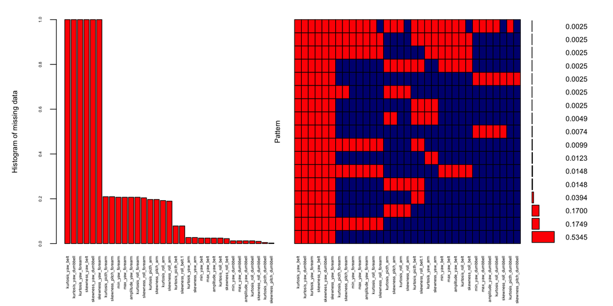

```r
aggr(training_agg_lines[, featuresToInvestigate],
     col = c('navyblue','red'),
     numbers = TRUE, prop = TRUE, sortVars = TRUE,
     labels = names(training_agg_lines[, featuresToInvestigate]),
     cex.axis = .4, cex.lab = .7, cex.numbers = .7, gap = 1,
     ylab = c("Histogram of missing data","Pattern"))
```

The random forest algorithm cannot cope with NAs. Corresponding lines should be filtered out or missing values should be imputed.  
Using the `mice` package, we can try to imput them:

```r
#imputing missing data
init <- mice(training_agg_lines, maxit = 0)
meth = init$method
predM = init$predictorMatrix

predM[, not_agg_features] <- 0
predM[, c(agg_features)] <- 1
predM[, c("user_name", agg_features, "classe")] = 1

meth[not_agg_features] <- ""
meth[agg_features] = "pmm"

imputed <- mice(training_agg_lines,
                method = meth, predictorMatrix = predM,
                m = 5, maxit = 10, seed = 500, print = FALSE)
completedData <- complete(imputed, 1)

countNA <- t(t(sapply(agg_features, function(feature) {
    sum(is.na(completedData[, feature]))
})))
featuresToDrop <- agg_features[countNA != 0]

cleanData <- completedData[, !(names(completedData) %in% featuresToDrop)]
```

Columns for which NAs remains have been filtered out.  
We can now fit a model:

```r
cluster <- makeCluster(detectCores() - 1) # convention to leave 1 core for OS
registerDoParallel(cluster)

featuresToKeep <- agg_features[ !(agg_features %in% featuresToDrop)]
formula <- as.formula(paste0("classe ~ ", paste(featuresToKeep, collapse = " + ")))

modelFit <- train(formula, method = "rf", data = cleanData,
                  trControl = trainControl(formula, method = "cv", number = 10))

stopCluster(cluster)
registerDoSEQ()
```

```r
confusionMatrix.train(modelFit)
```

```
## Cross-Validated (10 fold) Confusion Matrix
##
## (entries are percentual average cell counts across resamples)
##
##           Reference
## Prediction    A    B    C    D    E
##          A 25.4  4.4  1.5  0.7  0.7
##          B  0.7 14.0  1.7  0.0  2.5
##          C  0.5  0.5 13.1  1.5  0.2
##          D  0.2  0.0  0.7 13.8  0.7
##          E  0.0  0.5  0.2  1.0 15.3
##
##  Accuracy (average) : 0.8153
```

The average accuracy calculated during cross-validation is 81.53%.

Cross-validation was also used to tune parameters. We obtain the best accuracy (81.54%) with the `mtry` parameter set to 2.

Our final Model has an out-of-bag error rate of 17.24%.

Results obtained via the second approach are way less accurate than the first approach.  
Nevertheless, this result could probably be improved by collecting more data (only 406 aggregated lines).